# EasyVisa__Module3_Project

## Problem Statement

Businesses in the US require competent and skilled staff in order to remain competitive. Businesses frequently use both domestic and international labor to satisfy this demand.

Foreign workers are permitted to enter the United States for either temporary or permanent employment under the Immigration and Nationality Act (INA). Employers must adhere to strict rules when hiring foreign labor in order to protect American workers. The Office of Foreign Labor Certification (OFLC) oversees these regulations.

OFLC reviews employer applications for foreign workers and approves them only if there are not enough U.S. workers available for the job, and if the offered wages meet required standards.

## Objective

In 2016, OFLC processed nearly 776,000 employer applications for about 1.7 million job positions—a 9% increase from the previous year. As the number of applications grows every year, manually reviewing each case is becoming very difficult.

The increasing number of applicants every year calls for a Machine Learning based solution that can help in shortlisting the candidates having higher chances of VISA approval. OFLC has hired the firm EasyVisa for data-driven solutions. As a data scientist at EasyVisa the task is to analyze the data provided and, with the help of a classification model:

1. Facilitate the process of visa approvals.
2. Recommend a suitable profile for the applicants for whom the visa should be certified or denied based on the drivers that significantly influence the case status.

## Data Dictionary

The data contains the different attributes of the employee and the employer. The detailed data dictionary is given below.

- case_id: ID of each visa application
- continent: Information of continent of the employee
- education_of_employee: Information of education of the employee
- has_job_experience: Does the employee has any job experience? Y= Yes; N = No
- requires_job_training: Does the employee require any job training? Y = Yes; N = No
- no_of_employees: Number of employees in the employer's company
- yr_of_estab: Year in which the employer's company was established
- region_of_employment: Information of foreign worker's intended region of employment in the US
- prevailing_wage: Average wage paid to similarly employed workers in a specific occupation in the area of intended employment. The purpose of the prevailing wage is to ensure that the foreign worker is not underpaid compared to other workers offering the same or similar service in the same area of employment
- unit_of_wage: Unit of prevailing wage. Values include Hourly, Weekly, Monthly, and Yearly
- full_time_position: Is the position of work full-time? Y = Full-Time Position; N = Part-Time Position
- case_status: Flag indicating if the Visa was certified or denied

## Importing necessary libraries

```python
# importing core libraries for data manipulation and visualisation
import pandas as pd
import numpy as np
import matplotlib.pyplot as plt
import seaborn as sns

# importing scikit-learn utilities for preprocessing, model building and evaluation
from sklearn.model_selection import train_test_split
from sklearn.preprocessing import StandardScaler, LabelEncoder
from sklearn.metrics import classification_report, confusion_matrix, accuracy_score, f1_score, roc_auc_score, precision_score, recall_score

# importing classification algorithms
from sklearn.tree import DecisionTreeClassifier
from sklearn.ensemble import RandomForestClassifier, BaggingClassifier, AdaBoostClassifier, GradientBoostingClassifier

# importing techniques for imbalanced datasets
from imblearn.over_sampling import RandomOverSampler
from imblearn.under_sampling import RandomUnderSampler

# importing hyperparameter tuning tools
from sklearn.model_selection import GridSearchCV, RandomizedSearchCV

import warnings
warnings.filterwarnings('ignore')
```

## Loading the data

```python
from google.colab import drive
drive.mount('/content/drive')
```

```python
# loading data into a pandas dataframe
df = pd.read_csv("/content/drive/MyDrive/GL_Project/EasyVisa/EasyVisa.csv")
```

```python
# creating copy of the data
data = df.copy()
```

## Data background and contents

```python
# displaying first 5 rows of the data
data.head(5)
```

|  | case_id | continent | education_of_employee | has_job_experience | requires_job_training | no_of_employees | yr_of_estab | region_of_employment | prevailing_wage | unit_of_wage | full_time_position | case_status |
| --- | --- | --- | --- | --- | --- | --- | --- | --- | --- | --- | --- | --- |
| 0 | EZYV01 | Asia | High School | N | N | 14513 | 2007 | West | 592.2029 | Hour | Y | Denied |
| 1 | EZYV02 | Asia | Master's | Y | N | 2412 | 2002 | Northeast | 83425.6500 | Year | Y | Certified |
| 2 | EZYV03 | Asia | Bachelor's | N | Y | 44444 | 2008 | West | 122996.8600 | Year | Y | Denied |
| 3 | EZYV04 | Asia | Bachelor's | N | N | 98 | 1897 | West | 83434.0300 | Year | Y | Denied |
| 4 | EZYV05 | Africa | Master's | Y | N | 1082 | 2005 | South | 149907.3900 | Year | Y | Certified |

**Observation:**

The first 5 rows of the data along with the title of the column has been displayed here.

```python
# checking the shape of the data
data.shape
```

```
(25480, 12)
```

**Observation:**

The data.shape is used to generate the number of rows and columns. Here, the EasyVisa dataset has 25480 rows and 12 columns.

```python
# checking the attribute types
data.info()
```

```
<class 'pandas.core.frame.DataFrame'>
RangeIndex: 25480 entries, 0 to 25479
Data columns (total 12 columns):
 #   Column                 Non-Null Count  Dtype
---  ------                 --------------  -----
 0   case_id                25480 non-null  object
 1   continent              25480 non-null  object
 2   education_of_employee  25480 non-null  object
 3   has_job_experience     25480 non-null  object
 4   requires_job_training  25480 non-null  object
 5   no_of_employees        25480 non-null  int64
 6   yr_of_estab            25480 non-null  int64
 7   region_of_employment   25480 non-null  object
 8   prevailing_wage        25480 non-null  float64
 9   unit_of_wage           25480 non-null  object
 10  full_time_position     25480 non-null  object
 11  case_status            25480 non-null  object
dtypes: float64(1), int64(2), object(9)
memory usage: 2.3+ MB
```

**Observation:**

- There are 2 columns with integer (int64) values (no_of_employees, yr_of_estab).
- There is 1 column with float (float64) value (prevailing_wage).
- There are 9 columns with string (object) values (case_id, continent, education_of_employee, has_job_experience, requires_job_training, region_of_employment, unit_of_wage, full_time_position, case_status)

## Univariate Analysis

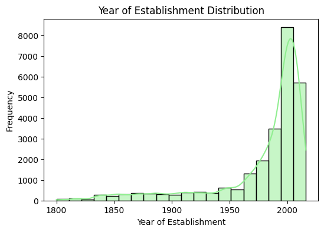

```python
# Year of Establishment

plt.figure(figsize=(6,4))
sns.histplot(df['yr_of_estab'], bins=20, kde=True, color='lightgreen')
plt.title('Year of Establishment Distribution')
plt.xlabel('Year of Establishment')
plt.ylabel('Frequency')
plt.show()
```

**Observation:**

The majority of establishments have been created after 1950 and very few establishments existed before 1900.

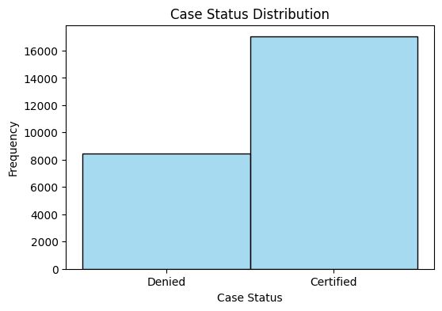

```python
# Case Status

plt.figure(figsize=(6,4))
sns.histplot(df['case_status'], palette="Set2", color="skyblue")
plt.title('Case Status Distribution')
plt.xlabel('Case Status')
plt.ylabel('Frequency')
plt.show()
```

**Observation:**

The approval rates are significantly higher than the denial rates with Certified (approx. 16000+) and Denied (approx. 8500).

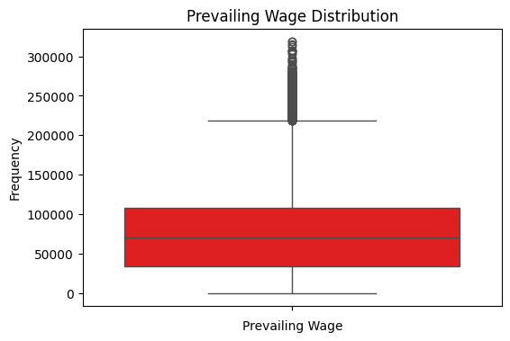

```python
# Prevailing Wages

plt.figure(figsize=(6,4))
sns.boxplot(y=df['prevailing_wage'], color='red')
plt.title('Prevailing Wage Distribution')
plt.xlabel('Prevailing Wage')
plt.ylabel('Frequency')
plt.show()
```

**Observation:**

- The median prevailing wage is around 65000 - 70000 dollars with the values concentrated between 40000 - 100000 dollars.
- There are several outliers above 200000 dollars which indicates some high wage cases.

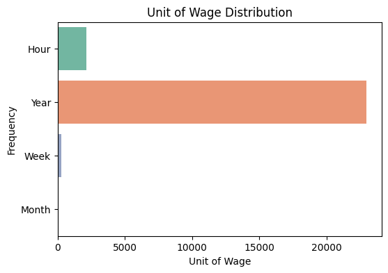

```python
# Unit of Wages

plt.figure(figsize=(6,4))
sns.countplot(df['unit_of_wage'], palette="Set2", color="skyblue")
plt.title('Unit of Wage Distribution')
plt.xlabel('Unit of Wage')
plt.ylabel('Frequency')
plt.show()
```

**Observation:**

- The wages are mostly reported on Yearly bases with approx. more than 20000 records.
- A smaller number are reported Hourly and a very few as Weekly or Monthly.
- This shows annual salaries dominate the dataset.

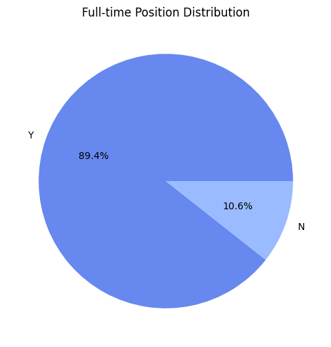

```python
# Full-time Position

plt.figure(figsize=(6,6))
df['full_time_position'].value_counts().plot.pie(autopct='%1.1f%%', colors=sns.color_palette('coolwarm'))
plt.title('Full-time Position Distribution')
plt.ylabel('')
plt.show()
```

**Observation:**

Most of the job roles in the dataset are full-time opportunities with about 89.4% of positions with Full-Time (Y) and 10.6% of positions with Non-Full-Time (N).

## Bivariate Analysis

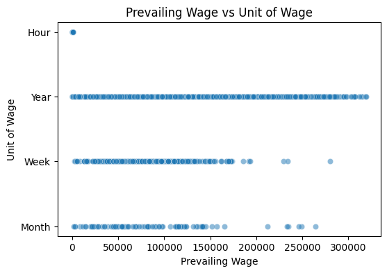

```python
# Prevailing Wage vs Unit of Wage

plt.figure(figsize=(6,4))
sns.scatterplot(x=df['prevailing_wage'], y=df['unit_of_wage'], alpha=0.5)
plt.title('Prevailing Wage vs Unit of Wage')
plt.xlabel('Prevailing Wage')
plt.ylabel('Unit of Wage')
plt.show()
```

**Observation:**

- Most of the wages are reported on Yearly basis with values ranging upto 300000 dollars.
- Weekly and Monthly wages also exist but are much fewer in number and the Hourly wage records are present with smaller values when compared to yearly wages.

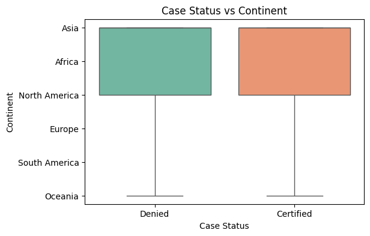

```python
# Case Status vs Continent

plt.figure(figsize=(6,4))
sns.boxplot(x=df['case_status'], y=df['continent'], palette="Set2")
plt.title('Case Status vs Continent')
plt.xlabel('Case Status')
plt.ylabel('Continent')
plt.show()
```

**Observation:**

The distribution of both Denied and Certified cases occur across all continents.

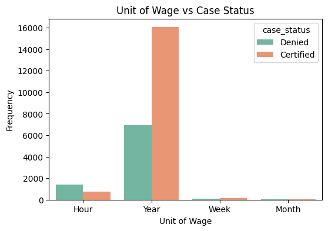

```python
# Unit of Wage vs Case Status

plt.figure(figsize=(6,4))
sns.countplot(x=df['unit_of_wage'], hue=df['case_status'], palette="Set2")
plt.title('Unit of Wage vs Case Status')
plt.xlabel('Unit of Wage')
plt.ylabel('Frequency')
plt.show()
```

**Observation:**

- Majority of the Yearly wages are Certified with denials being fewer but still significant.
- Hourly wages have more denials than certified case status.
- Weekly and monthly wages are less with both statuses present but relatively less.

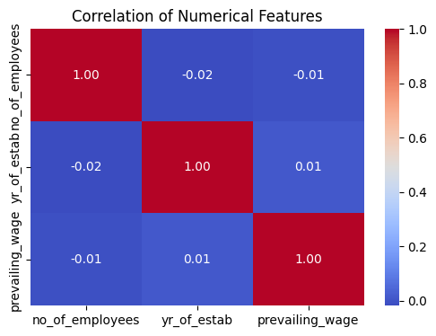

```python
# Correlation of Numerical Features

plt.figure(figsize=(6,4))
sns.heatmap(df.corr(numeric_only=True), annot=True, cmap='coolwarm', fmt='.2f')
plt.title('Correlation of Numerical Features')
plt.show()
```

**Observation:**

- The numeric variables are independent of each other and do not influence one another directly.
- There is almost no correlation among the numerical features:
  - Number of employees vs Year of Establishment (-0.02).
  - Employees vs Preailing Wage (-0.01).
  - Year of Establishment vs Prevailing Wage (0.01).

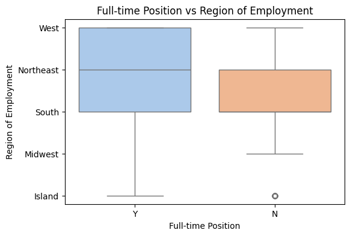

```python
# Full-time Position vs Region of Employment

plt.figure(figsize=(6,4))
sns.boxplot(x=df['full_time_position'], y=df['region_of_employment'], palette="pastel")
plt.title('Full-time Position vs Region of Employment')
plt.xlabel('Full-time Position')
plt.ylabel('Region of Employment')
plt.show()
```

**Observation:**

- Most of the full-time positions are concentrated in the West followed by Northeast and South regions.
- Non-full-time positions are distributed across regions but are slightly narrower.
- A few outliers exist, such as non-full-time job in Island regions.
- This shows that full-time employment is more dominant in major regions (West, Northeast), while part-time roles are scattered.